# Some title

## Results

Since the Kildin Saami model has never seen the characters not used in Kildin Saami, it can be assumed that it performs poorly with data from other languages. This is indeed the case, as plot below summarises. With the mixed test set Kildin Saami model has an arror rate of 9%.

In a monolingual Kildin Saami scenario Kildin Saami model outperforms the mixed model, but the difference is only 0.00565 percents. When compared in context, the similarity of performance in both models when used with Kildin Saami data is even more striking. In both tests Mansi accuracy is the best, which can be argued is caused by small amount of characters only present in Mansi.

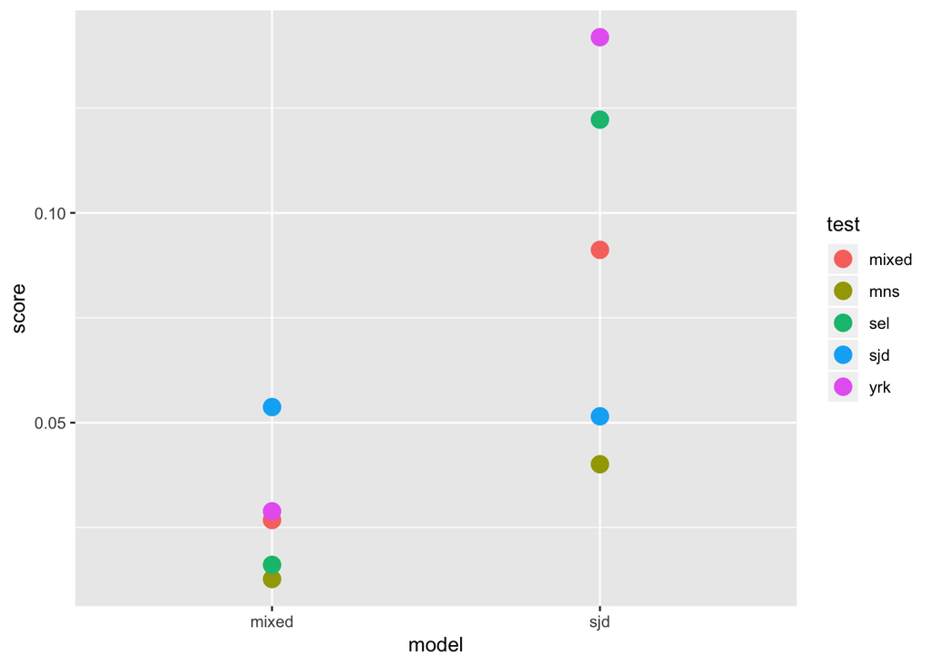

| lang | chars |
| --- | --- |
| mns | 46 |
| sel | 49 |
| sjd | 64 |
| yrk | 52 |

The whole character set used is presented below.

| char | mns | sjd | sel | yrk |
| --- | --- | --- | --- | --- |
| - | mns | sjd | sel | yrk |
| , | mns | sjd | sel | yrk |
| : | mns | sjd | sel | yrk |
| ! |  |  | sel | yrk |
| ? |  |  | sel |  |
| . | mns | sjd | sel | yrk |
| ( |  | sjd |  |  |
| ) |  | sjd |  |  |
| a | mns | sjd | sel | yrk |
| A | mns | sjd | sel |  |
| ā |  |  | sel |  |
| æ |  |  | sel |  |
| c | mns | sjd | sel | yrk |
| C |  | sjd | sel |  |
| ç |  |  |  | yrk |
| d | mns | sjd | sel | yrk |
| D |  | sjd |  |  |
| d̦ |  | sjd |  |  |
| e | mns | sjd | sel | yrk |
| E | mns | sjd |  |  |
| ə |  | sjd | sel | yrk |
| Ə |  | sjd | sel |  |
| f |  | sjd |  |  |
| g |  | sjd | sel | yrk |
| G |  | sjd |  |  |
| h | mns | sjd |  | yrk |
| H | mns | sjd |  | yrk |
| ꜧ | mns |  |  | yrk |
| i | mns | sjd | sel | yrk |
| I | mns | sjd | sel |  |

[output cut: 55 more lines]

Since the models are trained in extremely narrow domain, it comes to mind whether the results are truly generalizable into any other context. Ideally additional tests could be carried out with similar text, but which wouldn’t be directly related.

## Conclusions

One recommendation that arises from our work is that training an OCR model can be done very easily with the current technology. Fast iterative process where the first model is trained with very small data, and used to create little bit larger dataset, on which the same procedure is repeated, appears to be a very effective and effortless approach.

## Further work

The parallel texts should be transformed into contemporary orthographies, and could be employed in variety of purposes. For example, bootstrapping embryonic treebanks with Universal Dependencies project could be very interesting way to make improve the digital infrastructure of these languages in a rather dramatic and visible way.